# Production and Income

Session 1

Luis F. Gómez L.

luis.gomezl@unimilitar.edu.co

Distance Learning Faculty

26 January, 2026

# Please Read Me

- Check the message **Welcome greeting** published in Announcements forum.
- Dear student please edit your profile uploading a photo where your face is clearly visible.
- If you want to participate, please fill out the following survey: **Primer corte 30% > Learning Activities > Tu opinión sobre la economía colombiana**
- This presentation is based on (Cardenas, 2020, Chapter 2)
- **Purpose**
  - Understand how production is measured using the concept of Gross Domestic Product (GDP)

# Gross Domestic Product (GDP)

- What is? (Lequiller & Blades, 2014, p. 19)
  - **Product**: means that we are trying to measure production without double counting

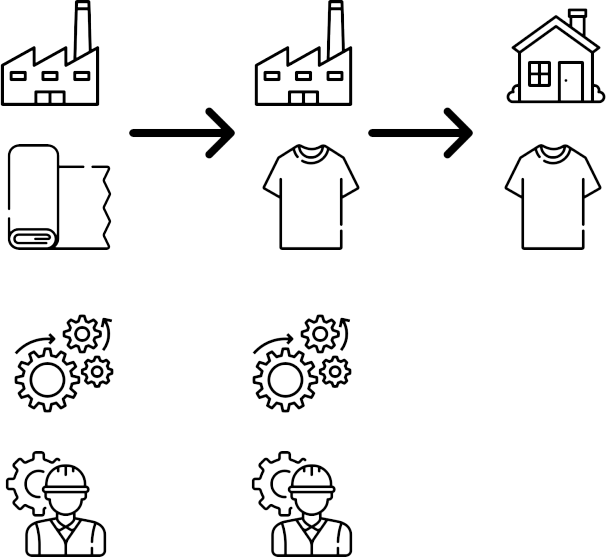

Figure 1: Measuring production without double counting

- What is? (Lequiller & Blades, 2014, p. 19)
  - **Domestic**: means that the production to be taken into account is the one that is carried within a certain territory clearly delimited

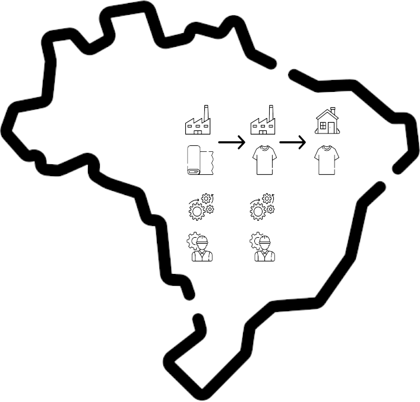

Figure 2: Delimiting production geographically

- What is? (Lequiller & Blades, 2014, p. 19)
  - **Gross**: means that depreciation is not deducted (in economy it is called consumption of fixed capital). In other words, the decrease in the value of the assets used in the production process due to physical deterioration, foreseeable wear or accidental damage is not deducted

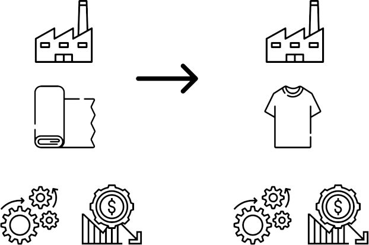

Figure 3: Not deducting depreciation

- How is measure?
  - 3 equivalent[^1] approaches are used (Lequiller & Blades, 2014, p. 31)
    - **Output/Production approach**: adding the aggregate value of all the production units in a territory, plus taxes minus subsidies on products
    - **Income approach**: adding all the incomes that are perceived because of the contribution to the production process
    - **Expenditure/Final demand approach**: adding all uses that firms, non-profit institutions, government bodies, households and the external sector give to production
  - Gross Domestic Product is a flow so it is measured over a period of time. Usually you can find information about this variable in an monthly, quarterly or yearly periodicity
  - Initially Gross Domestic Product is expressed in **current** Local Currency Units (LCU)

Table 1: Output/Production approach I (Colombia, 2025-Q3)

| Concepto | Miles de Millones - COP<sup>a</sup> |
| --- | --- |
| Agricultura, ganadería, caza, silvicultura y pesca | 46,860 |
| Explotación de minas y canteras | 17,496 |
| Industrias manufactureras | 46,786 |
| Suministro de electricidad, gas, vapor y aire acondicionado; Distribución de agua; evacuación y tratamiento de aguas residuales, gestión de desechos y actividades de saneamiento ambiental | 18,533 |
| Construcción | 18,909 |
| Comercio al por mayor y al por menor; reparación de vehículos automotores y motocicletas; Transporte y almacenamiento; Alojamiento y servicios de comida | 90,364 |
| Información y comunicaciones | 9,977 |

<sup>a</sup> Preliminary data at current prices  
Source: DANE - Cuentas Nacionales Trimestrales - Producto Interno Bruto desde el enfoque de la producción a precios corrientes - Cuadro 1 Datos originales  
Last update: 2025-11-18

Table 2: Output/Production approach II (Colombia, 2025-Q3)

| Concepto | Miles de Millones - COP<sup>a</sup> |
| --- | --- |
| Actividades financieras y de seguros | 19,972 |
| Actividades inmobiliarias | 34,529 |
| Actividades profesionales, científicas y técnicas; Actividades de servicios administrativos y de apoyo | 29,579 |
| Administración pública y defensa; planes de seguridad social de afiliación obligatoria; Educación; Actividades de atención de la salud humana y de servicios sociales | 72,921 |
| Actividades artísticas, de entretenimiento y recreación y otras actividades de servicios; Actividades de los hogares individuales en calidad de empleadores; actividades no diferenciadas de los hogares… | 18,730 |
| Valor agregado bruto | 424,655 |
| Impuestos menos subvenciones sobre los productos | 51,063 |
| Producto interno bruto | 475,718 |

<sup>a</sup> Preliminary data at current prices  
Source: DANE - Cuentas Nacionales Trimestrales - Producto Interno Bruto desde el enfoque de la producción a precios corrientes - Cuadro 1 Datos originales  
Last update: 2025-11-18

Table 3: Income approach (Colombia, 2025-Q3)

| Concepto | Miles de Millones - COP<sup>a</sup> |
| --- | --- |
| Remuneración de los asalariados | 156,764 |
| Impuestos menos subvenciones | 60,004 |
| Excedente Bruto de Explotación | 144,262 |
| Ingreso Mixto | 114,688 |
| Producto Interno Bruto | 475,718 |

<sup>a</sup> Preliminary data at current prices  
Source: DANE - Cuentas Nacionales Trimestrales - PIB por Ingreso - S1 Total Economía  
Last update: 2025-12-26

Table 4: Expenditure/Final demand approach (Colombia, 2025-Q3)

| Concepto | Miles de Millones - COP<sup>a</sup> |
| --- | --- |
| Gasto de consumo final individual de los hogares y las ISFLH<sup>b</sup> | 344,223 |
| Gasto de consumo final del gobierno general | 70,023 |
| Formación bruta de capital | 92,531 |
| Exportaciones | 70,621 |
| Importaciones | 101,679 |
| Producto Interno Bruto | 475,718 |

<sup>a</sup> Preliminary data at current prices  
<sup>b</sup> Instituciones sin fines de lucro que sirven a los hogares  
Source: DANE - Cuentas Nacionales Trimestrales - PIB por Ingreso - S1 Total Economía  
Last update: 2025-11-18

- What adjustments are applied?[^2]
  - **Inflation adjustments**
    - GDP is expressed in **constant** Local Currency Units (LCU)
  - **Season and calendar adjustments**
    - In Colombia this is applied to quarterly GDP (DANE, 2018)
  - **Population adjustments**
    - GDP is expressed in per capita terms
  - **Purchase Power Parity (PPP) adjustment**
    - It is used only to make international comparisons and it is led by the International Comparison Program (ICP)
- An inflation adjustment is necessary because an arbitrary quantity of local currency units don’t have the same purchase power in different periods

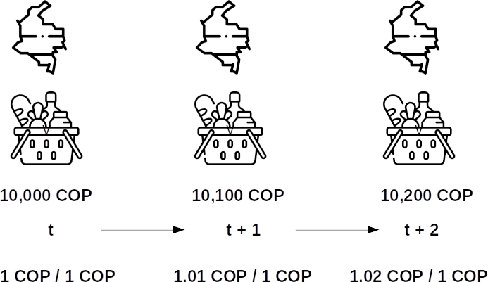

Figure 4: Applying an inflation adjustment

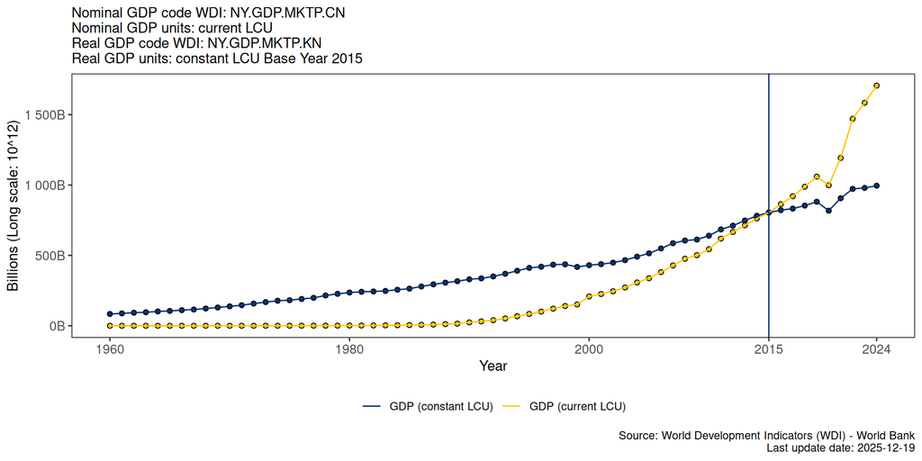

Figure 5: Nominal and real GDP Colombia

- Some countries have more population than others so they can produce more. Therefore it is necessary to express the GDP per inhabitant

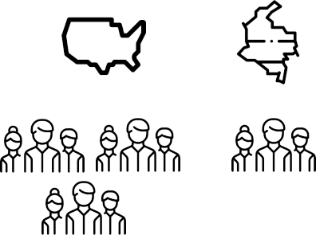

Figure 6: Applying a population adjustment

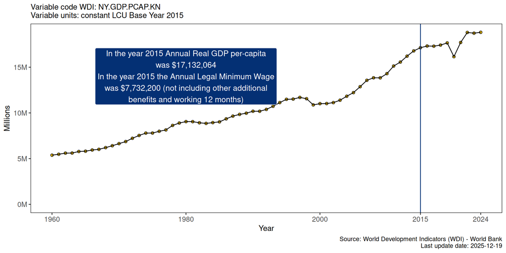

Figure 7: Real GDP per-capita Colombia

- Purchasing power parity
  - The amount of products that 1 local currency unit of an economy can buy in another economy

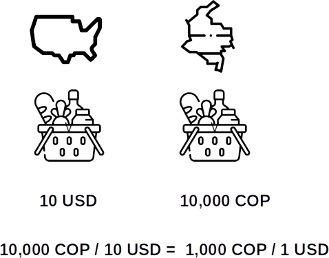

Figure 8: Applying a purchasing power parity adjustment

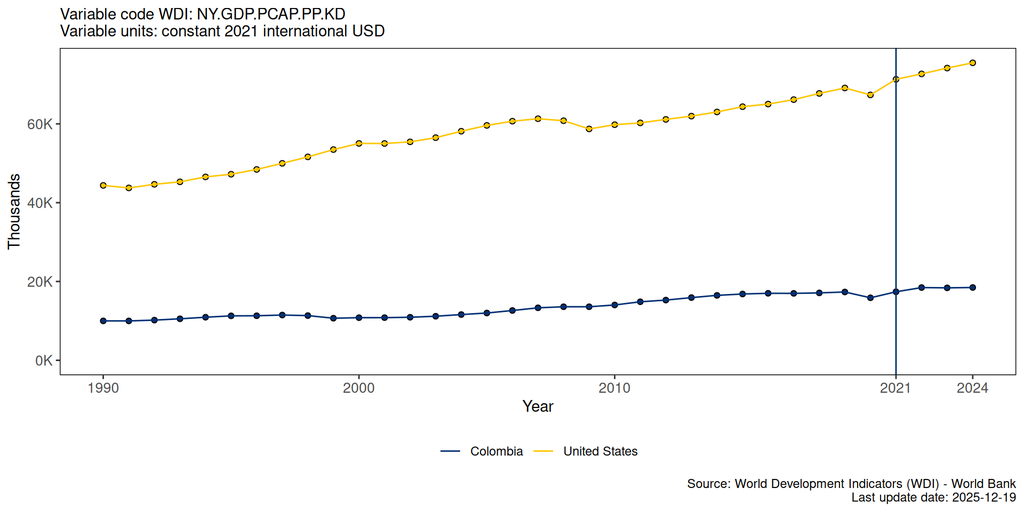

Figure 9: GDP per-capita purchasing power parity for Colombia and USA

# Economic Growth

- The most common metric used to measure economic growth is the annual percent growth of real GDP per capita.
  - If the periodicity of real GDP per capita is **yearly** and we don’t want to make international comparisons the formula is:

$$\frac{\text{GDP per capita constant LCU}_t - \text{GDP per capita constant LCU}_{t-1}}{\text{GDP per capita constant LCU}_{t-1}} \times 100$$

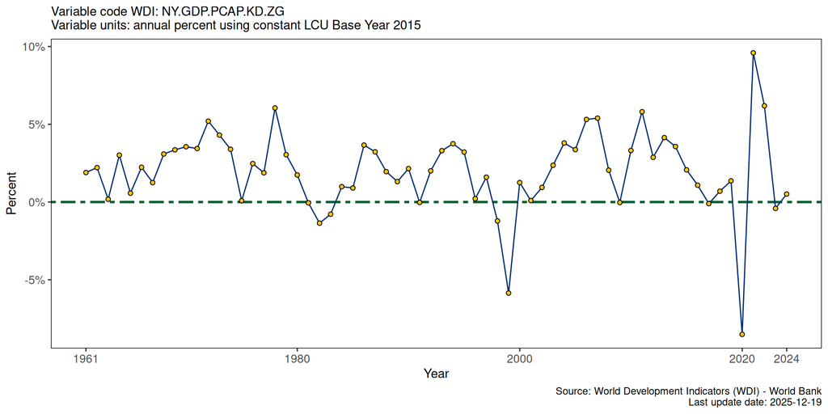

Figure 10: Growth real GDP per-capita Colombia

# Acknowledgments

- To my family that supports me
- To the taxpayers of Colombia and the [**UMNG students**](https://www.umng.edu.co/estudiante) who pay my salary
- To the [**Business Science**](https://www.business-science.io/) and [**R4DS Online Learning**](https://www.rfordatasci.com/) communities where I learn [**R**](https://www.r-project.org/about.html) and [**$\pi$-thon**](https://www.python.org/about/)
- To the [**R Core Team**](https://www.r-project.org/contributors.html), the creators of [**RStudio IDE**](https://posit.co/download/rstudio-desktop/), [**Positron**](https://positron.posit.co/), [**Quarto**](https://quarto.org/) and the authors and maintainers of the packages [**tidyverse**](https://CRAN.R-project.org/package=tidyverse), [**readxl**](https://CRAN.R-project.org/package=readxl), [**gt**](https://CRAN.R-project.org/package=gt), [**wbstats**](https://CRAN.R-project.org/package=wbstats), [**scales**](https://CRAN.R-project.org/package=scales) and [**tinytex**](https://CRAN.R-project.org/package=tinytex) for allowing me to access these tools without paying for a license
- To the icon designers [**Brecris**](https://www.flaticon.com/authors/becris), [**Freepik**](https://www.flaticon.com/authors/freepik), [**Iconixar**](https://www.flaticon.com/authors/iconixar), [**Monkik**](https://www.flaticon.com/authors/monkik) and [**Eucalyp**](https://www.flaticon.com/authors/eucalyp) from [**Flaticon**](https://www.flaticon.com/) for letting me use their work in this presentation as a free user

# References

Cardenas, M. (2020). *Introducción a la Economía Colombiana* (4th ed.). Alfaomega.

DANE. (2018). *Cuentas Nacionales Trimestrales Ajuste Estacional*. https://www.dane.gov.co/files/investigaciones/boletines/pib/ajuste-estacional-pib.pdf

Hyndman, R. J., & Athanasopoulos, G. (2021). *Forecasting: Principles and Practice (3rd ed)*. https://Otexts.com/fpp3/

Lequiller, F., & Blades, D. (2014). *Understanding National Accounts: Second Edition*. OECD. https://doi.org/10.1787/9789264214637-en

## Footnotes

[^1]: In practice, discrepancies may occur
[^2]: For an introduction of the first 3 adjustments check out (Hyndman & Athanasopoulos, 2021, Chapter 3, Section 3.1 Transformations and adjustments)